# Part2

Anika John

2023-05-11

## Step 1. Visually check the compositions

WT samples contain reasonable proportion of dorsal telencephalic cells, while the KO samples have very few of them. Accoring to paper, KO samples correspond to knockout of GLI3, a transcription factor that drives dorsal and ventral telencephalic fate.

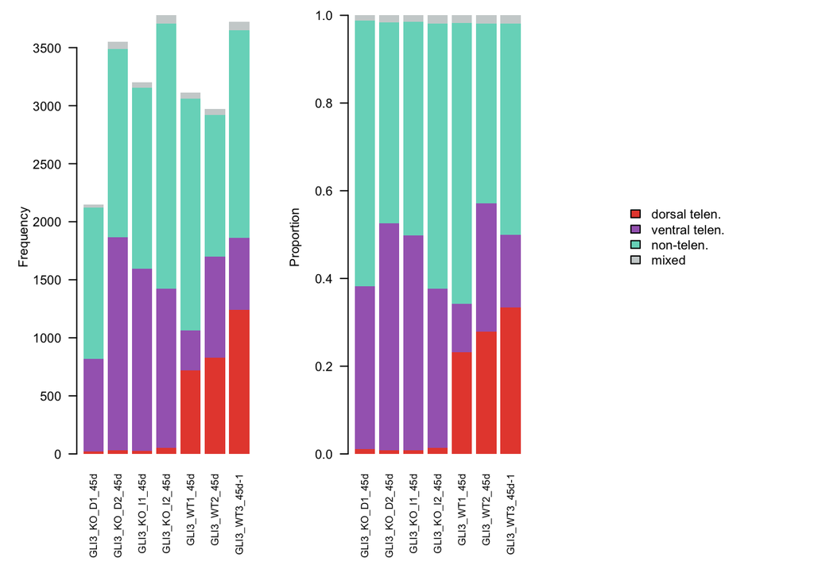

```r
freq <- table(seurat$region, seurat$organoid)
prop <- apply(freq,2,function(x) x/sum(x))

layout(matrix(1:3,nrow=1)); par(mar=c(8,5,1,1))
barplot(freq, col=c("#E74C3C","#A569BD","#76D7C4","#CCD1D1"),
        border=NA, las=2, ylab="Frequency", cex.names = 0.8)
barplot(prop, col=c("#E74C3C","#A569BD","#76D7C4","#CCD1D1"),
        border=NA, las=2, ylab="Proportion", cex.names = 0.8)
plot.new()
legend("left", fill=c("#E74C3C","#A569BD","#76D7C4","#CCD1D1"), legend=rownames(freq), bty="n")
```

## 2-1. Composition comparison with Fisher’s exact test

```
##           region  oddsratio  pval_fisher  padj_fisher
## 1  dorsal telen. 0.02585209 0.0000000000 0.0000000000
## 2 ventral telen. 3.41036390 0.0000000000 0.0000000000
## 3     non-telen. 1.10071983 0.0003788091 0.0007576182
## 4          mixed 0.88051062 0.2308498731 0.2308498731
```

## 2-2. Composition comparison with generalized linear model (GLM)

ANOVA = Analysis of Variance, we compare the withing group variance to the between group variance. If groups have an actual effect, the variance should differ. The between group variance comes from the deviation of the observed values from GLM model predicted values.

```r
freq_glm_aov <- function(samples, conditions, have_identity){
  sample_conditions <- unique(data.frame(sample = samples, condition = conditions))
  sample_conditions <- setNames(sample_conditions$condition, sample_conditions$sample)

  #freq = count table of cells that are either 'non-tel' or not per sample
  #
  freq <- table(samples, factor(have_identity, levels=c(TRUE,FALSE)))
  m <- glm(freq ~ sample_conditions[rownames(freq)], family = "binomial")
  aov <- anova(m, test = "Chisq")
  res <- setNames(c(coef(m)[2], aov$Pr[2]), c("coef_glm","pval_aov"))
  return(res)
}

region_enrichment <- data.frame(region_enrichment,
  # loop and test every region
  t(sapply(levels(seurat$region), function(region){
    freq_glm_aov(samples = seurat$organoid,
                 conditions = factor(seurat$GLI3_status, levels=c("WT","KO")),
                 seurat$region == region)
  })),
  row.names=NULL)
region_enrichment$padj_aov <- p.adjust(region_enrichment$pval_aov)
region_enrichment
```

```
##           region  oddsratio  pval_fisher  padj_fisher    coef_glm     pval_aov
## 1  dorsal telen. 0.02585209 0.0000000000 0.0000000000 -3.65548865 0.0000000000
## 2 ventral telen. 3.41036390 0.0000000000 0.0000000000  1.22678293 0.0000000000
## 3     non-telen. 1.10071983 0.0003788091 0.0007576182  0.09596969 0.0003648231
## 4          mixed 0.88051062 0.2308498731 0.2308498731 -0.12726065 0.2199637786
##       padj_aov
## 1 0.0000000000
## 2 0.0000000000
## 3 0.0007296462
## 4 0.2199637786
```

*Interpretation*:  
“The GLM model can estimates a coefficient of the KO condition in relative to WT”, so the coefficient tells us if a cell type is enriched or depleted in KO relative to the WT. The padj_aov gives us a p-value for this statement. Hence, Ventral and non-telen. cells seem to be enriched, dorsal telen seem depleted.

## Step 3. Problems of those statistics and robustness of differences

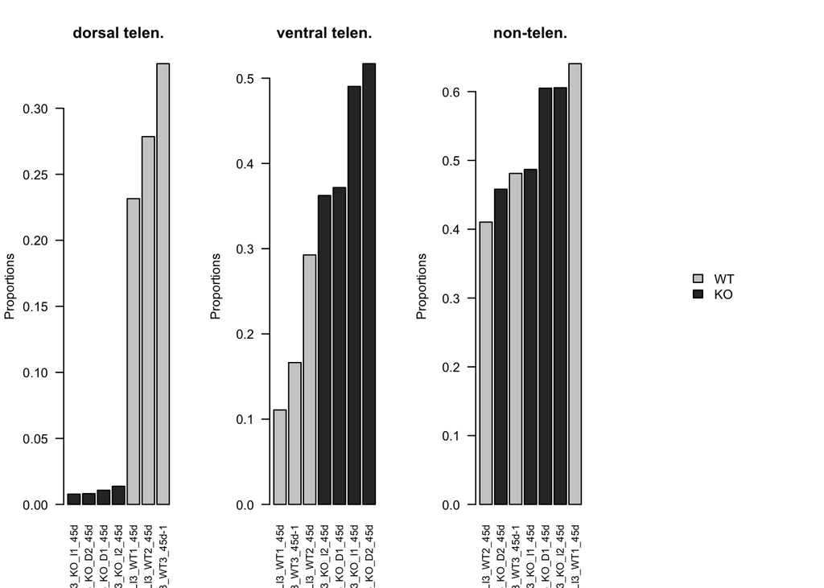

```r
org_status <- unique(data.frame(organoid=seurat$organoid,
                                GLI3_status=factor(seurat$GLI3_status, levels=c("WT","KO"))))
org_status <- setNames(org_status$GLI3_status, org_status$organoid)

layout(matrix(1:4,nrow=1))
for(region in c("dorsal telen.","ventral telen.","non-telen.")){
  props <- setNames(sapply(sort(unique(seurat$organoid)), function(organoid)
                      mean(seurat$region[seurat$organoid == organoid] == region)),
                   sort(unique(seurat$organoid)))
  barplot(props[order(props)],
          col = ifelse(org_status[names(props)[order(props)]] == "WT", "#cdcdcd", "#303030"),
          ylab = "Proportions", main = region, las = 2, cex.names = 0.8, srt=30)
}
plot.new()
legend("left", fill = c("#cdcdcd","#303030"), legend = c("WT","KO"), bty="n")
```

For non-telencephalon region, there seems to be one WT outlier. KO samples also not consistent.

#### Solution 2. Leave-one-sample-out and its variants

```r
region_enrichment_drop1 <- data.frame(
  # loop and test every region
  do.call(rbind, lapply(levels(seurat$region), function(region){
    data.frame(region = region,
               dropped = sort(unique(seurat$organoid)),

               # loop and excl one sample each
               t(sapply(sort(unique(seurat$organoid)), function(org){
                 idx_cells <- which(seurat$organoid != org)
                 freq_fisher(conditions = factor(seurat$GLI3_status, levels=c("KO","WT")),
                             have_identity = seurat$region == region)
               }))
    )
  })),
  row.names=NULL)

region_enrichment_drop1$padj_fisher <- p.adjust(region_enrichment_drop1$pval_fisher)
region_enrichment_drop1
```

```
##            region        dropped  oddsratio  pval_fisher padj_fisher
## 1   dorsal telen. GLI3_KO_D1_45d 0.02585209 0.0000000000 0.000000000
## 2   dorsal telen. GLI3_KO_D2_45d 0.02585209 0.0000000000 0.000000000
## 3   dorsal telen. GLI3_KO_I1_45d 0.02585209 0.0000000000 0.000000000
## 4   dorsal telen. GLI3_KO_I2_45d 0.02585209 0.0000000000 0.000000000
## 5   dorsal telen.   GLI3_WT1_45d 0.02585209 0.0000000000 0.000000000
## 6   dorsal telen.   GLI3_WT2_45d 0.02585209 0.0000000000 0.000000000
## 7   dorsal telen. GLI3_WT3_45d-1 0.02585209 0.0000000000 0.000000000
## 8  ventral telen. GLI3_KO_D1_45d 3.41036390 0.0000000000 0.000000000
## 9  ventral telen. GLI3_KO_D2_45d 3.41036390 0.0000000000 0.000000000
## 10 ventral telen. GLI3_KO_I1_45d 3.41036390 0.0000000000 0.000000000
## 11 ventral telen. GLI3_KO_I2_45d 3.41036390 0.0000000000 0.000000000
## 12 ventral telen.   GLI3_WT1_45d 3.41036390 0.0000000000 0.000000000
## 13 ventral telen.   GLI3_WT2_45d 3.41036390 0.0000000000 0.000000000
## 14 ventral telen. GLI3_WT3_45d-1 3.41036390 0.0000000000 0.000000000
## 15     non-telen. GLI3_KO_D1_45d 1.10071983 0.0003788091 0.005303327
## 16     non-telen. GLI3_KO_D2_45d 1.10071983 0.0003788091 0.005303327
## 17     non-telen. GLI3_KO_I1_45d 1.10071983 0.0003788091 0.005303327
## 18     non-telen. GLI3_KO_I2_45d 1.10071983 0.0003788091 0.005303327
## 19     non-telen.   GLI3_WT1_45d 1.10071983 0.0003788091 0.005303327
## 20     non-telen.   GLI3_WT2_45d 1.10071983 0.0003788091 0.005303327
## 21     non-telen. GLI3_WT3_45d-1 1.10071983 0.0003788091 0.005303327
## 22          mixed GLI3_KO_D1_45d 0.88051062 0.2308498731 1.000000000
## 23          mixed GLI3_KO_D2_45d 0.88051062 0.2308498731 1.000000000
## 24          mixed GLI3_KO_I1_45d 0.88051062 0.2308498731 1.000000000
## 25          mixed GLI3_KO_I2_45d 0.88051062 0.2308498731 1.000000000
## 26          mixed   GLI3_WT1_45d 0.88051062 0.2308498731 1.000000000
## 27          mixed   GLI3_WT2_45d 0.88051062 0.2308498731 1.000000000
## 28          mixed GLI3_WT3_45d-1 0.88051062 0.2308498731 1.000000000
```

```r
label_permut <- function(samples, conditions, num_permut = 100){
  sample_conditions <- unique(data.frame(sample = samples, condition = conditions))
  sample_conditions <- setNames(sample_conditions$condition, sample_conditions$sample)

  num_samples_per_conditions <- table(sample_conditions)
  max_num_permut <- Reduce("*", sapply(2:length(num_samples_per_conditions), function(i)
                                  choose(n = sum(num_samples_per_conditions[(i-1):length(num_samples_per_conditions)]),
                                         k = num_samples_per_conditions[i])
                                ))

  num_permut <- min(c(num_permut, max_num_permut))

  # generate permutations of sample-condition pairs
  if (num_permut / max_num_permut < 0.2){ # random label shuffling
    permut_sample_conditions <- lapply(1:num_permut, function(i)
      setNames(sample(sample_conditions),names(sample_conditions)))

  } else{ # exact label permutations
    permuts <- utils::combn(1:length(sample_conditions), num_samples_per_conditions[1])
    for(i in 2:length(num_samples_per_conditions)){
      permuts <- do.call(cbind, lapply(1:ncol(permuts), function(j){
        permuts_istep <- utils::combn(setdiff(1:length(sample_conditions), permuts[,j]),
                                      num_samples_per_conditions[i])
        permuts_after <- apply(permuts_istep, 2, function(x) c(permuts[,j], x))
      }))
    }

    conds <- rep(sort(unique(sample_conditions)), num_samples_per_conditions)
    permut_sample_conditions <- lapply(sample(ncol(permuts))[1:num_permut], function(i)
      setNames(conds, names(sample_conditions)[permuts[,i]])[names(sample_conditions)]
    )
  }

  return(setNames(data.frame(as.data.frame(permut_sample_conditions),
                             row.names=names(sample_conditions)), NULL))
}
permut_sample_conditions <- label_permut(seurat$organoid,
                                         factor(seurat$GLI3_status, levels=c("WT","KO")))
permut_sample_conditions
```

```
##
## GLI3_WT3_45d-1 KO KO KO WT WT WT WT KO WT WT KO KO WT KO KO WT KO WT WT KO KO
## GLI3_KO_D1_45d WT KO KO KO KO KO KO WT WT WT KO WT WT KO WT WT KO KO KO WT KO
## GLI3_KO_D2_45d WT KO WT WT WT KO KO WT KO KO KO KO KO WT KO KO KO KO WT KO WT
## GLI3_KO_I1_45d KO WT KO KO WT WT KO KO KO KO KO WT KO WT WT WT WT KO KO WT WT
## GLI3_KO_I2_45d KO KO WT KO KO KO KO KO WT KO WT KO KO KO WT KO WT WT WT KO KO
## GLI3_WT1_45d   KO WT WT WT KO KO WT WT KO WT WT KO KO WT KO KO WT KO KO WT KO
## GLI3_WT2_45d   WT WT KO KO KO WT WT KO KO KO WT WT WT KO KO KO KO WT KO KO WT
##
## GLI3_WT3_45d-1 KO WT KO KO WT KO KO KO KO WT KO KO WT WT
## GLI3_KO_D1_45d KO KO KO WT KO WT WT WT KO WT KO WT KO KO
## GLI3_KO_D2_45d WT KO WT WT KO WT KO KO KO WT WT KO KO WT
## GLI3_KO_I1_45d WT WT KO KO KO WT KO KO WT KO KO KO WT KO
## GLI3_KO_I2_45d WT KO KO WT WT KO WT KO WT KO WT WT WT KO
## GLI3_WT1_45d   KO WT WT KO WT KO KO WT KO KO KO WT KO KO
## GLI3_WT2_45d   KO KO WT KO KO KO WT WT WT KO WT KO KO WT
```

Would now need to change `factor(seurat$GLI3_status, levels=c("WT","KO"))` accordingly for Fisher and ANOVA input. Seems a bit overkill, eventhough more samples than in example.

```r
#cannot try this option because don't have ct information in seurat object
# freq_glm_aov_2 <- function(conditions, have_identity, samples){
#   m1 <- glm(have_identity ~ conditions + samples, family = binomial)
#   m0 <- glm(have_identity ~ samples, family = binomial)
#   aov <- anova(m1, m0, test = "Chisq")
#
#   res <- setNames(c(coef(m1)["conditions"], aov$Pr[2]), c("coef","pval"))
#   return(res)
# }
#
# ct_enrich_glm <- freq_glm_aov_2(conditions = factor(seurat$genotype, levels=c("WT","KO")),
#                                 have_identity = seurat$ct == ct1,
#                                 samples = seurat$sample)
```

## Part 3. Differential expression analysis

Focusing on the Cluster-0 in the example data set, which should be the ventral telencephalic neurons based on the marker expression, we define the transcriptomic similarity between two samples as the Pearson’s correlation coefficient between the average gene expression levels of cells in the two samples along the highly variable genes.

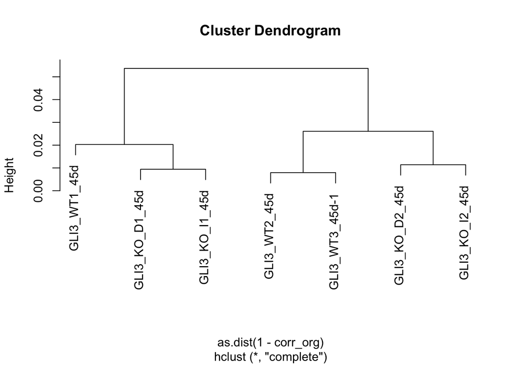

```r
seurat_ventral <- subset(seurat, subset = seurat_clusters == 0) %>%
  FindVariableFeatures()

avg_expr_org <- sapply(sort(unique(seurat$organoid)), function(org)
  rowMeans(seurat_ventral@assays$RNA@data[,which(seurat_ventral$organoid == org)]))
#correlation of gene expression vectors, all combinations
corr_org <- cor(avg_expr_org[VariableFeatures(seurat_ventral),])
plot(hclust(as.dist(1-corr_org)))
```

*Interpretation*:  
One wild type sample seems very distinct from the others. There seem to be two classes of knock out samples.

### Wilcoxon test for DE

```r
DE_wilcoxauc_ventral <- wilcoxauc(seurat_ventral, group_by = "GLI3_status") %>%
  filter(group == "KO") %>%
  mutate(DE = abs(logFC)>log(1.1) & padj < 0.01) %>%
  mutate(DEG = ifelse(abs(logFC)>log(1.1) & padj < 0.01, feature, NA))

# Log fold change = log(FC) Usually, the transformation is log at base 2, so the interpretation is straightforward: a log(FC) of 1 means twice as expressed
#log2(FoldChange) = x; FoldChange=2^x
```

Are KO samples differently expressed than WT samples?  
We would expect so because the WT samples contain more dorsal telen cells = different cell composition = diffent expression patterns.

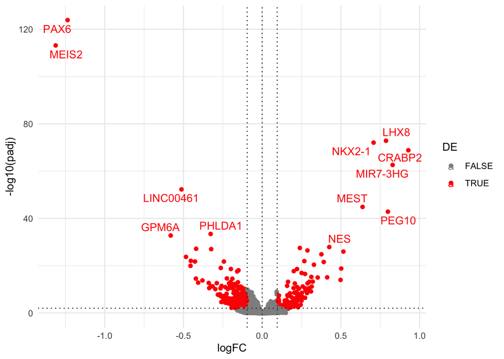

```r
ggplot(DE_wilcoxauc_ventral, aes(x = logFC, y = -log10(padj), col=DE, label=DEG)) +
  geom_point() +
  geom_text_repel() +
  geom_vline(xintercept=c(-log(1.1), log(1.1), 0), col="#303030", linetype="dotted") +
  geom_hline(yintercept=-log10(0.01), col="#303030", linetype="dotted") +
  scale_color_manual(values=c("#909090", "red")) +
  theme_minimal()
```

*Interpretation*:  
PAX6, MEIS2, (DLK1) = involved in dorsoventral pattering, absence of GLI3 downregulates them

From Paper:  
“This analysis suggests that the GLI3 targets HES5, EMX2 and PAX6 are major drivers of dorsal telencephalic fate, whereas FOXG1 and DMRTA1 activate ventral telencephalic fate”

We can see down regulation of PAX6 and less dorsal telenpathic cells in KO = supports statement.

LHX-8 and NKX2-1 involved in the MGE (medial ganglionic eminence == type of neurons) induction program are up-regulated in the absence of GLI3.

```r
det_rate <- rowMeans(seurat_ventral@assays$RNA@data)
meta <- seurat_ventral@meta.data %>% mutate(GLI3_status = factor(GLI3_status, levels=c("WT","KO")))
dds <- DESeqDataSetFromMatrix(seurat_ventral@assays$RNA@counts[det_rate > 0.05,],
                              colData=meta,
                              design = ~ GLI3_status)
sizeFactors(dds) <- calculateSumFactors(seurat_ventral@assays$RNA@counts[det_rate > 0.05,])
dds <- DESeq(dds, test="LRT", reduced=~1, useT=TRUE, minmu=1e-6, minReplicatesForReplace=Inf)
```

```
## -- note: fitType='parametric', but the dispersion trend was not well captured by the
##    function: y = a/x + b, and a local regression fit was automatically substituted.
##    specify fitType='local' or 'mean' to avoid this message next time.
```

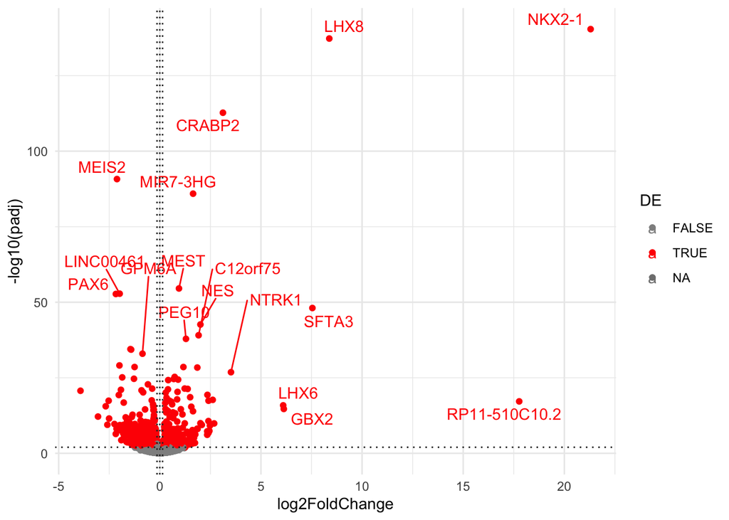

```r
DE_deseq2_ventral <- results(dds) %>% as.data.frame() %>%
  tibble::rownames_to_column("gene") %>%
  mutate(DE = abs(log2FoldChange)>log2(1.1) & padj < 0.01) %>%
  mutate(DEG = ifelse(abs(log2FoldChange)>log2(1.1) & padj < 0.01, gene, NA))

ggplot(DE_deseq2_ventral, aes(x = log2FoldChange, y = -log10(padj), col=DE, label=DEG)) +
  geom_point() +
  geom_text_repel(max.overlaps = 20) +
  geom_vline(xintercept=c(-log2(1.1), log2(1.1), 0), col="#303030", linetype="dotted") +
  geom_hline(yintercept=-log10(0.01), col="#303030", linetype="dotted") +
  scale_color_manual(values=c("#909090", "red")) +
  theme_minimal()
```

Upregulation of LHX-8 and NKX2-1 becomes more clearly visible.

```r
DE_deseq2_ventral %>% filter(gene == 'PAX6' | gene == 'LINC00461')
```

```
##        gene  baseMean log2FoldChange     lfcSE    stat       pvalue
## 1 LINC00461 0.4302037      -1.984007 0.1314642 251.408 1.280793e-56
## 2      PAX6 1.6405465      -2.172601 0.1387781 250.706 1.821904e-56
##           padj   DE       DEG
## 1 1.474742e-53 TRUE LINC00461
## 2 1.835568e-53 TRUE      PAX6
```

```r
# to do DE test for one gene
aov_DE <- function(expr, cond, covar = NULL, family = "gaussian", test = NULL){
  if (is.null(covar)) covar <- data.frame(X_const = 1)
  dat <- data.frame(y = expr,
                    cond = cond,
            covar)
  m <- glm(y ~ ., family = family, data = dat)
  m0 <- glm(y ~ . - cond, family = family, data = dat)

  if (is.null(test)){
    test <- "F"
    if (ifelse(is(family, "family"), family$family, family) %in% c("binomial","poisson"))
      test <- "Chisq"
  }
  aov <- anova(m, m0, test = test)

  res <- c(coef(m)[grep("^cond",names(coef(m)))], aov$Pr[2])
  names(res)[length(res)] <- "pval"
  return(res)
}

DE_aov <- data.frame(t(pbsapply(which(det_rate > 0.05), function(i)
  aov_DE(expr = seurat_ventral@assays$RNA@data[i,],
         cond = factor(seurat_ventral$GLI3_status, levels=c("WT","KO")),
         covar = data.frame(cov = log10(seurat_ventral$nCount_RNA))))), row.names=NULL)
DE_aov$padj <- p.adjust(DE_aov$pval, method="BH")
DE_aov <- data.frame(gene = names(which(det_rate > 0.05)), DE_aov) %>%
  mutate(DE = abs(condKO)>log(1.1) & padj < 0.01) %>%
  mutate(DEG = ifelse(abs(condKO)>log(1.1) & padj < 0.01, gene, NA))

DE_aov_bin <- data.frame(t(pbsapply(which(det_rate > 0.05), function(i)
  aov_DE(expr = seurat_ventral@assays$RNA@data[i,] > 0,
         cond = factor(seurat_ventral$GLI3_status, levels=c("WT","KO")),
         covar = data.frame(cov = seurat_ventral$nCount_RNA),
         family = "binomial"))), row.names=NULL)
```

[output not shown]

[output cut: 12 more lines]

[output not shown]

[output not shown]

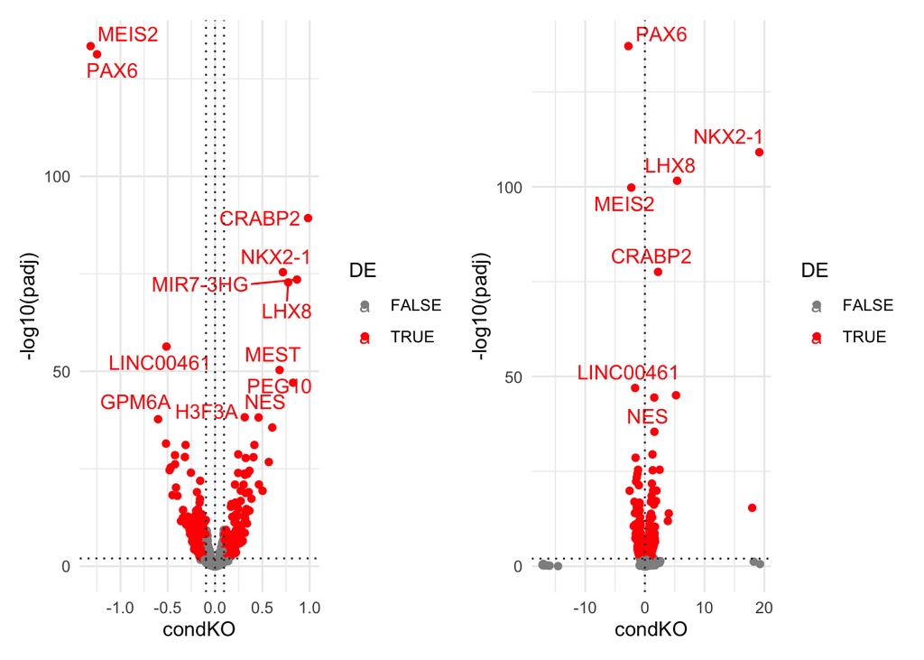

```r
DE_aov_bin$padj <- p.adjust(DE_aov_bin$pval, method="BH")
DE_aov_bin <- data.frame(gene = names(which(det_rate > 0.05)), DE_aov_bin) %>%
  mutate(DE = padj < 0.01) %>%
  mutate(DEG = ifelse(padj < 0.01, gene, NA))

p1 <- ggplot(DE_aov, aes(x = condKO, y = -log10(padj), col=DE, label=DEG)) +
  geom_point() +
  geom_text_repel(max.overlaps = 20) +
  geom_vline(xintercept=c(-log(1.1), log(1.1), 0), col="#303030", linetype="dotted") +
  geom_hline(yintercept=-log10(0.01), col="#303030", linetype="dotted") +
  scale_color_manual(values=c("#909090", "red")) +
  theme_minimal()
p2 <- ggplot(DE_aov_bin, aes(x = condKO, y = -log10(padj), col=DE, label=DEG)) +
  geom_point() +
  geom_text_repel(max.overlaps = 20) +
  geom_vline(xintercept=0, col="#303030", linetype="dotted") +
  geom_hline(yintercept=-log10(0.01), col="#303030", linetype="dotted") +
  scale_color_manual(values=c("#909090", "red")) +
  theme_minimal()

p1 | p2
```

Results are comparable to the ones before